# Session 6: Homework 3

# 5 Challenge 2:GDP components over time and among countries

At the risk of oversimplifying things, the main components of gross domestic product, GDP are personal consumption (C), business investment (I), government spending (G) and net exports (exports - imports).

The GDP data we will look at is from the [United Nations’ National Accounts Main Aggregates Database](https://unstats.un.org/unsd/snaama/Downloads), which contains estimates of total GDP and its components for all countries from 1970 to today. We will look at how GDP and its components have changed over time, and compare different countries and how much each component contributes to that country’s GDP. The file we will work with is [GDP and its breakdown at constant 2010 prices in US Dollars](http://unstats.un.org/unsd/amaapi/api/file/6) and it has already been saved in the Data directory. Have a look at the Excel file to see how it is structured and organised.

```r
# load the data
UN_GDP_data  <-  read_excel(here::here("data", "Download-GDPconstant-USD-countries.xls"),
sheet="Download-GDPconstant-USD-countr",
skip=2)
```

The first thing you need to do is to tidy the data, as it is in wide format and you must make it into long, tidy format. Please express all figures in billions (divide values by `1e9`, or $10^9$), and you want to rename the indicators into something shorter.

```r
tidy_GDP_data  <-  UN_GDP_data %>%
  pivot_longer(cols = 4:51, names_to = 'Year', values_to = 'Value') %>%
  filter(IndicatorName %in% c('Gross capital formation',
'Exports of goods and services',
'Imports of goods and services',
'General government final consumption expenditure',
'Household consumption expenditure (including Non-profit institutions serving households)',
'Gross Domestic Product (GDP)')) %>%
  mutate(Value = Value/1e9) %>%

   # rename indicators using case_when and mutate
  mutate(IndicatorName = case_when(IndicatorName == 'Gross capital formation' ~ 'Gross capital formation',
  IndicatorName == 'Exports of goods and services' ~ 'Exports',
  IndicatorName == 'Imports of goods and services' ~ 'Imports',
  IndicatorName == 'General government final consumption expenditure' ~ 'Government expenditure',
  IndicatorName == 'Household consumption expenditure (including Non-profit institutions serving households)' ~ 'Household expenditure',
  IndicatorName == 'Gross Domestic Product (GDP)' ~ 'GDP_given'))

glimpse(tidy_GDP_data)
```

```
## Rows: 63,072
## Columns: 5
## $ CountryID     <dbl> 4, 4, 4, 4, 4, 4, 4, 4, 4, 4, 4, 4, 4, 4, 4, 4, 4, 4,...
## $ Country       <chr> "Afghanistan", "Afghanistan", "Afghanistan", "Afghani...
## $ IndicatorName <chr> "Household expenditure", "Household expenditure", "Ho...
## $ Year          <chr> "1970", "1971", "1972", "1973", "1974", "1975", "1976...
## $ Value         <dbl> 5.07, 4.84, 4.70, 5.21, 5.59, 5.65, 5.68, 6.15, 6.30,...
```

```r
# Let us compare GDP components for these 3 countries
country_list <- c("United States","India", "Germany")
```

First, can you produce this plot?

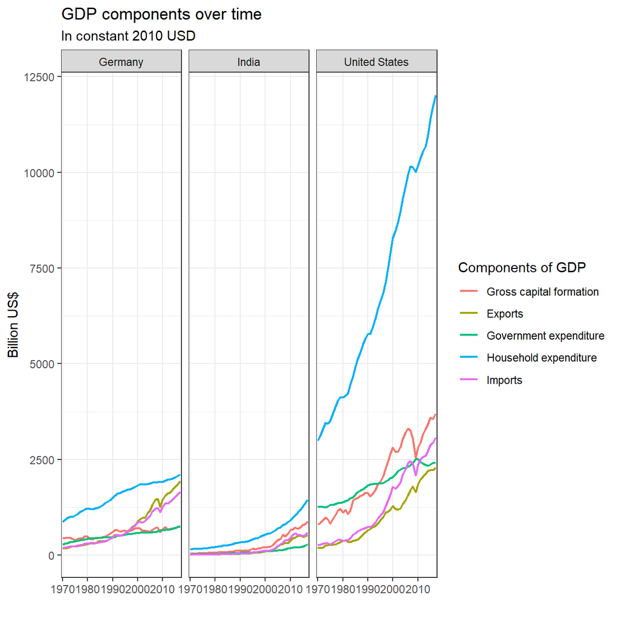

```r
plot1_data <- tidy_GDP_data %>%

  # filter for country and indicator
  filter(Country %in% country_list,
         IndicatorName != 'GDP_given') %>%

  # order indicators s.t they are in the same order as in the plot
  mutate(IndicatorName = factor(IndicatorName, levels = c('Gross capital formation',
  'Exports',
  'Government expenditure',
  'Household expenditure',
  'Imports')))

plot1_data %>%   ggplot() +
  geom_line(aes(x = Year, y = Value, group = IndicatorName, color = IndicatorName), size = 0.8) +
  scale_x_discrete(breaks = c(1970,1980,1990,2000,2010)) +
  scale_color_discrete(name = 'Components of GDP') +
  facet_wrap(~ Country) +
  labs(x = '',
       y = 'Billion US$',
       title = 'GDP components over time',
       subtitle = 'In constant 2010 USD') +
  theme_bw()
```

Secondly, recall that GDP is the sum of Household Expenditure (Consumption *C*), Gross Capital Formation (business investment *I*), Government Expenditure (G) and Net Exports (exports - imports). Even though there is an indicator `Gross Domestic Product (GDP)` in your dataframe, I would like you to calculate it given its components discussed above.

> What is the % difference between what you calculated as GDP and the GDP figure included in the dataframe?

```r
# Here,I first arrange the data into wide format and thus this would be much easier to read and analyze
tidy_GDP_data_calculation  <-  UN_GDP_data %>%
  pivot_longer(cols = 4:51, names_to = 'Year', values_to = 'Value') %>%
  filter(IndicatorName %in% c('Gross capital formation',
'Exports of goods and services',
'Imports of goods and services',
'General government final consumption expenditure',
'Household consumption expenditure (including Non-profit institutions serving households)',
'Gross Domestic Product (GDP)')) %>%
  mutate(Value = Value/1e9) %>%

  # rename indicators using case_when and mutate
  mutate(IndicatorName = case_when(IndicatorName == 'Gross capital formation' ~ 'I',
  IndicatorName == 'Exports of goods and services' ~ 'X',
  IndicatorName == 'Imports of goods and services' ~ 'IM',
  IndicatorName == 'General government final consumption expenditure' ~ 'G',
  IndicatorName == 'Household consumption expenditure (including Non-profit institutions serving households)' ~ 'C',
  IndicatorName == 'Gross Domestic Product (GDP)' ~ 'GDP_given'))%>%

  # Arrange the data in wide format
   pivot_wider(names_from='IndicatorName',values_from='Value') %>%

# Calculate the variable using formula
   mutate(calculated_GDP = C+I+G+X-IM,na.rm=FALSE)%>%

# Calculate the difference
   mutate(percent_difference=(GDP_given-calculated_GDP)/GDP_given)

skim(tidy_GDP_data_calculation$percent_difference)
```

Data summary

| Name | tidy_GDP_data_calculation… |
| --- | --- |
| Number of rows | 10560 |
| Number of columns | 1 |
| _______________________ |  |
| Column type frequency: |  |
| numeric | 1 |
| ________________________ |  |
| Group variables | None |

**Variable type: numeric**

| skim_variable | n_missing | complete_rate | mean | sd | p0 | p25 | p50 | p75 | p100 | hist |
| --- | --- | --- | --- | --- | --- | --- | --- | --- | --- | --- |
| data | 986 | 0.91 | 0 | 0.09 | -1.16 | -0.02 | 0 | 0.02 | 0.55 | ▁▁▁▇▁ |

> Replicate the plot

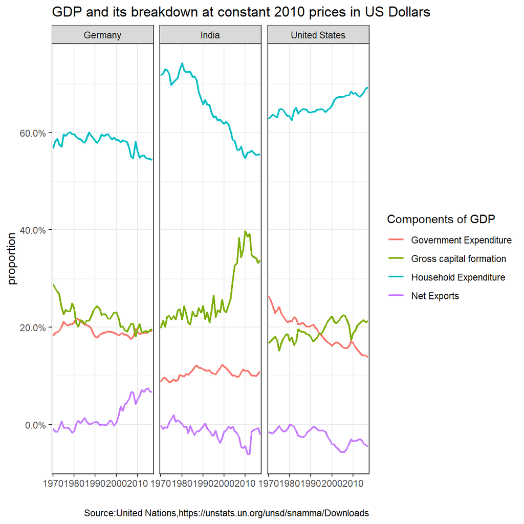

```r
tidy_GDP_data_plot2  <-  UN_GDP_data %>%
  pivot_longer(cols = 4:51, names_to = 'Year', values_to = 'Value') %>%
  filter(IndicatorName %in% c('Gross capital formation',
    'Exports of goods and services',
    'Imports of goods and services',
    'General government final consumption expenditure',
    'Household consumption expenditure (including Non-profit institutions serving households)',
    'Gross Domestic Product (GDP)')) %>%
  mutate(Value = Value/1e9) %>%

  # rename indicators using case_when and mutate
  mutate(IndicatorName = case_when(IndicatorName == 'Gross capital formation' ~ 'I',
  IndicatorName == 'Exports of goods and services' ~ 'X',
  IndicatorName == 'Imports of goods and services' ~ 'IM',
  IndicatorName == 'General government final consumption expenditure' ~ 'G',
  IndicatorName == 'Household consumption expenditure (including Non-profit institutions serving households)' ~ 'C',
  IndicatorName == 'Gross Domestic Product (GDP)' ~ 'GDP_given')) %>%

  # Arrange the data in wide format
   pivot_wider(names_from='IndicatorName',values_from='Value') %>%

  # Create a variable called Net Exports
   mutate(NX=X-IM) %>%

  # Calculate proportion
   mutate('Government Expenditure'=G/GDP_given,'Gross capital formation'=I/GDP_given,
          'Household Expenditure'=C/GDP_given,'Net Exports'=NX/GDP_given) %>%

   select(1:3,9:14) %>%

  # Make the data into long format again
  pivot_longer(cols='Government Expenditure':'Net Exports',names_to='IndicatorName',values_to='proportions')

# Let us compare GDP components for these 3 countries
country_list <- c("United States","India", "Germany")

tidy_GDP_data_plot2 %>%

  # filter for country and indicator
  filter(Country %in% country_list) %>%

  # order indicators s.t they are in the same order as in the plot
  mutate(IndicatorName = factor(IndicatorName, levels = c('Government Expenditure',
                                                          'Gross capital formation',
                                                          'Household Expenditure',
                                                          'Net Exports'))) %>%
  # Code for the plot
  ggplot() +
  geom_line(aes(x = Year, y = proportions, group = IndicatorName, color = IndicatorName), size = 0.8) +

  #adjust the scale
  scale_x_discrete(breaks = c(1970,1980,1990,2000,2010)) +

  #adjust scale color
  scale_color_discrete(name = 'Components of GDP') +
  facet_wrap(~ Country) +
  labs(x = '',
       y = 'proportion',
       title = 'GDP and its breakdown at constant 2010 prices in US Dollars',
       caption = 'Source:United Nations,https://unstats.un.org/unsd/snamma/Downloads')  +

  #adjust decimal place on y-axis
  scale_y_continuous(labels=label_percent(accuracy=0.1))+

  theme_bw()
```

> What is this last chart telling you? Can you explain in a couple of paragraphs the different dynamic among these three countries?